# Machine learning analysis of RNA-seq data

Author

Prof. Francesca Finotello

# Introduction

Machine learning is a branch of AI that learns patterns from data to make predictions or decisions. In *supervised learning*, models are trained on labeled data to map inputs to outputs, performing *regression* (predicting quantitative values) or *classification* (predicting categories). In *unsupervised learning*, models identify patterns in unlabeled data, for example through clustering, which groups similar data points, or dimensionality reduction techniques such as principal component analysis (PCA), which reduce data dimensionality while preserving as much information content as possible.

In this set of exercises, we will apply a selection of machine learning techniques to investigate cancer RNA-seq data. We will start from a dataset from the [Cancer Cell Line Encyclopedia (CCLE)](https://sites.broadinstitute.org/ccle/), which contains RNA-seq data summarized in a gene transcripts per million (TPM) matrix across more than 100 cancer cell lines from different tumor types.

# Exercises

## Data access and initialization

The CCLE matrix of TPM and the sample/cell line annotations can be downloaded in the form or an R file (“CCLE_data.rda”) from the course OpenOLAT entry at [this link](https://lms.uibk.ac.at/auth/RepositoryEntry/5944246577/CourseNode/113086671488191). **Note**: you need to be logged in to access the file.

Once saved in the working directory, the object can be loaded into RStudio using the following command; In case the file is not located working directory, make sure to specify the correct file path.

```r
load("CCLE_data.rda", verbose = TRUE)
```

```
Loading objects:
  tpm
  tissue
```

The loaded data include a data.frame, called `tpm`, with the TPM across 57,820 genes and 141 cancer cell lines/ samples.

```r
dim(tpm)
```

```
[1] 57820   141
```

We can inspect the first three rows and columns, to see that the genes are saved as Ensembl identifiers (“ENSG”), and that the first three samples (A101D, A2058, and A375) come from skin cancer cell lines:

```r
tpm[1:3, 1:3]
```

```
                A101D_SKIN A2058_SKIN A375_SKIN
ENSG00000000003      10.20      15.67     15.91
ENSG00000000005       0.00       0.00      0.00
ENSG00000000419     136.86      97.03    194.76
```

The second object loaded, called `tissue`, is a vector of length 141 reporting the tissue origin of every cell line in the dataset:

```r
length(tissue)
```

```
[1] 141
```

```r
head(tissue)
```

```
    A101D_SKIN     A2058_SKIN      A375_SKIN ASPC1_PANCREAS   AU565_BREAST
        "SKIN"         "SKIN"         "SKIN"     "PANCREAS"       "BREAST"
   BT20_BREAST
      "BREAST"
```

```r
tail(tissue)
```

```
   WM793_SKIN     WM88_SKIN   WM983B_SKIN YAPC_PANCREAS  ZR751_BREAST
       "SKIN"        "SKIN"        "SKIN"    "PANCREAS"      "BREAST"
ZR7530_BREAST
     "BREAST"
```

We can use the `table` function to count the number of cell line for each tissue origin:

```r
table(tissue)
```

```
tissue
  BREAST PANCREAS     SKIN
      51       41       49
```

Before we begin the analysis, let’s set the seed of the random number generator as indicated below to ensure reproducible plots and results:

```r
set.seed(1234)
```

```r
log_tpm <- log(tpm + 1)
```

## Exercise 1

In this exercise we will perform PCA of this dataset for 2D-visualization. PCA is performed with the `prcomp`, which expects observations on the rows of the input data, and variables on columns. As our dataset `log_tpm` has instead observations (i.e., samples/cell lines_ on the columns, and variables (i.e., genes) on the rows, we need to first *transpose* it using the `t` function:

```r
pca_result <- prcomp(t(log_tpm))
```

The results are saved in a variable called `pca_result`, which is a list (also) containing:

- `pca_result$x`: sample coordinates in principal component space;
- `pca_result$rotation`: loadings, i.e. contribution of each gene to each principal component (PC);
- `pca_result$sdev`: standard deviations of the PC.

We can now extract the sample coordinates along the first PS (`pc1`) and second PC (`pc2`):

```r
pc1 <- pca_result$x[, 1]
pc2 <- pca_result$x[, 2]
```

We can now plot the samples in PC space (PC2 vs. PC1), using dots (`pch = 19`) to represent the samples:

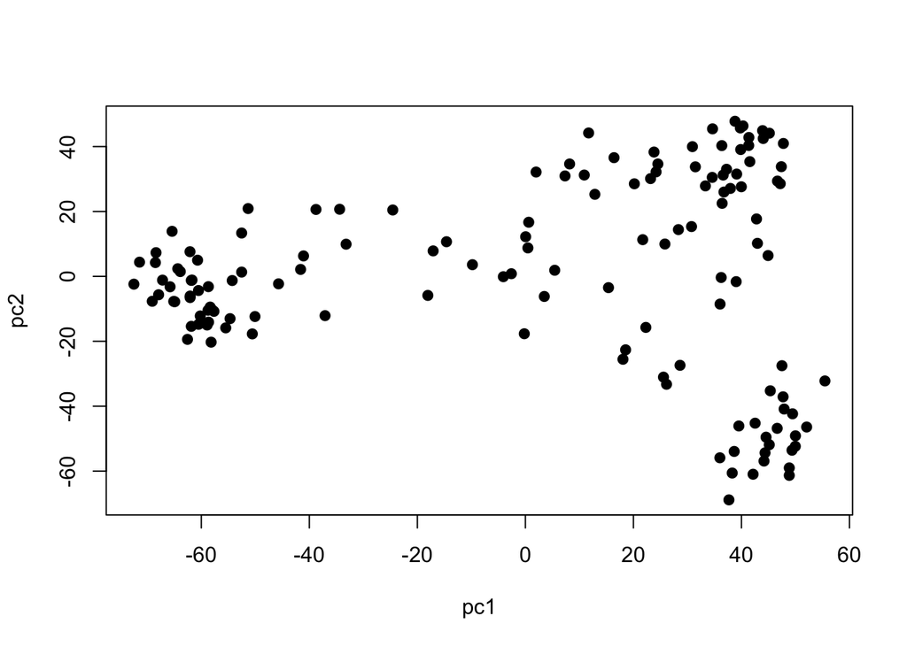

```r
plot(
  pc1, pc2,
  pch = 19
)
```

From the standard deviation, we can calculate the variance explained by the first two PC (rounded to 1 digit) and add this information to the plot axes; the `paste0` function is used to paste together strings of text (between quotes) and the values stored in variables like `var1` and `var2`:

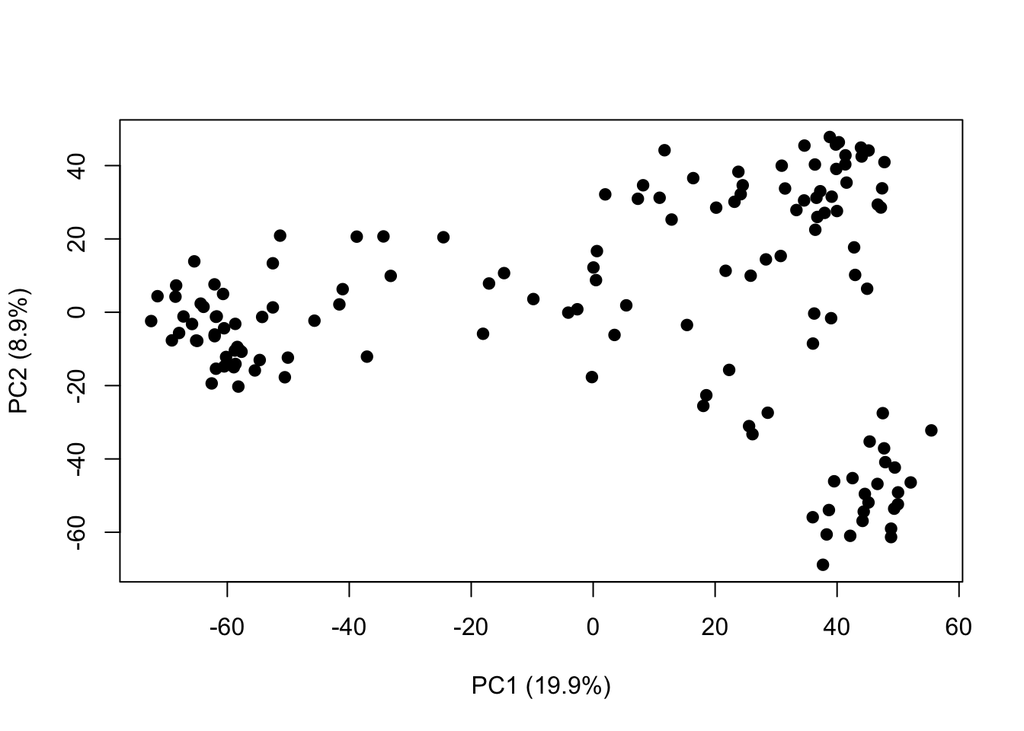

```r
var1 <- round(pca_result$sdev[1]^2 / 100, 1)
var2 <- round(pca_result$sdev[2]^2 / 100, 1)
plot(
  pc1, pc2,
  pch = 19,
  xlab = paste0("PC1 (", var1, "%)"),
  ylab = paste0("PC2 (", var2, "%)")
)
```

By definig a palette based on three colors, we can color the points according to their tissue of origin:

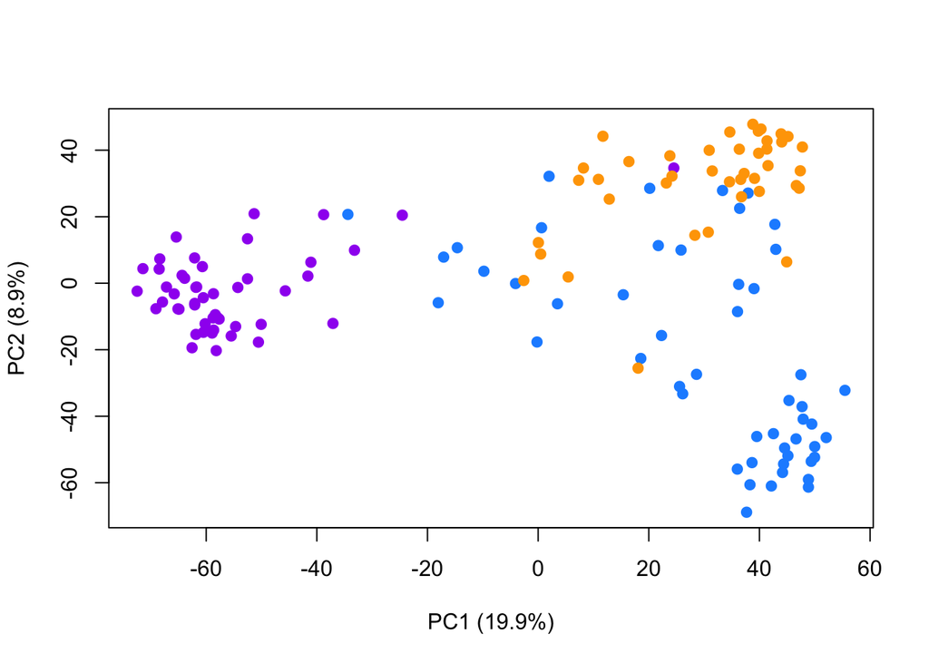

```r
cols <- c("dodgerblue", "orange", "purple")
plot(
  pc1, pc2,
  pch = 19,
  xlab = paste0("PC1 (", var1, "%)"),
  ylab = paste0("PC2 (", var2, "%)"),
  col = cols[factor(tissue)]
)
```

To be able to interpret the results, we add a legend:

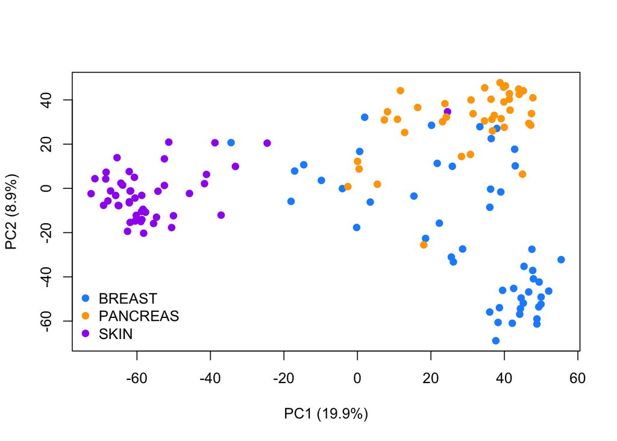

```r
plot(
  pc1, pc2,
  pch = 19,
  xlab = paste0("PC1 (", var1, "%)"),
  ylab = paste0("PC2 (", var2, "%)"),
  col = cols[factor(tissue)]
)
legend(
  "bottomleft",
  legend = levels(factor(tissue)),
  col = cols,
  pch = 19,
  bty = "n"
)
```

❓ **Question:** Which is the cancer type showing the most marked separation from the other two?

**Click to see the answer**

**Answer:**

The biggest difference in this dataset is between skin and the other two tissues (breast/pancreas), as they are separated by the widest gap along the PC1 axis.

❓ **Question:** What are the cancer types showing the biggest similarity?

**Click to see the answer**

**Answer:**

Breast and pancreas cancer cell lines show some overlap in PC space, which suggests that they may share certain molecular molecular programs, which are distinct instead from those found in the skin.

❓ **Question:** Which is the cancer type showing the largest heterogeneity?

**Click to see the answer**

**Answer:**

The wide spread of the breast cancer samples indicates a larger heterogeneity, which could suggest the presence of different molecular subtypes.

## Exercise 2

We can extract the loadings of PC1 and PC2:

```r
load1 <- pca_result$rotation[,1]
load2 <- pca_result$rotation[,2]
```

We can sort them by absolute value, so that features with the strongest positive or negative association with PC1 or PC2 appear first.

```r
load1 <- load1[order(abs(load1), decreasing = TRUE)]
load2 <- load2[order(abs(load2), decreasing = TRUE)]
```

Now, with `head`, we can inspect the first three genes associated with PC1 and their loadings, ans use [Gene Cards](https://www.genecards.org/) to under=stand their biological role:

```r
head(load1, 3)
```

```
ENSG00000160307 ENSG00000171345 ENSG00000113140
    -0.06374611      0.06234631     -0.05989141
```

- [ENSG00000160307; S100B](https://www.genecards.org/cgi-bin/carddisp.pl?gene=S100B&keywords=ENSG00000160307) (negatively associated with PC1)
- [ENSG00000171345; KRT19](https://www.genecards.org/cgi-bin/carddisp.pl?gene=KRT19&keywords=ENSG00000171345) (positively associated with PC1)
- [ENSG00000113140; SPARC](https://www.genecards.org/cgi-bin/carddisp.pl?gene=SPARC&keywords=ENSG00000113140) (negatively associated with PC1)

❓ **Question:** Which are the top-three genes associated with PC2?

**Click to see the answer**

**Answer:**

```r
head(load2, 3)
```

```
ENSG00000198959 ENSG00000148346 ENSG00000122861
     0.05679559      0.05396201      0.05387196
```

- [ENSG00000198959; TGM2](https://www.genecards.org/cgi-bin/carddisp.pl?gene=TGM2&keywords=ENSG00000198959) (positively associated with PC2)
- [ENSG00000148346; LCN2](https://www.genecards.org/cgi-bin/carddisp.pl?gene=LCN2&keywords=ENSG00000148346) (positively associated with PC2)
- [ENSG00000122861; PLAU](https://www.genecards.org/cgi-bin/carddisp.pl?gene=PLAU&keywords=ENSG00000122861) (positively associated with PC2)

We can color the PCA plot according to the expression level of the gene most negatively associated with PC1 (ENSG00000160307), allowing us to visualize that this gene is more highly expressed in samples with more negative PC1 values.

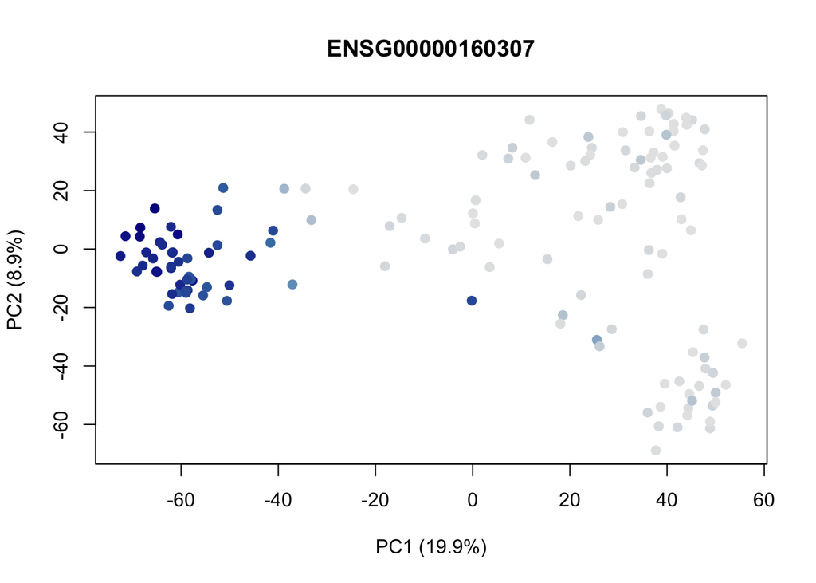

```r
gene <- "ENSG00000160307"
expr <- as.numeric(log_tpm[gene,])
pal <- colorRampPalette(c("grey90", "steelblue", "darkblue"))(100)
plot(pc1, pc2,
     pch = 19,

       xlab = paste0("PC1 (", var1, "%)"),
  ylab = paste0("PC2 (", var2, "%)"),
     main = gene,
       col = pal[cut(expr, breaks = 100)]
)
```

❓ **Question:** How can we do the same plot, but for the gene with the largest positive association (ENSG00000171345)?

**Click to see the answer**

**Answer:**

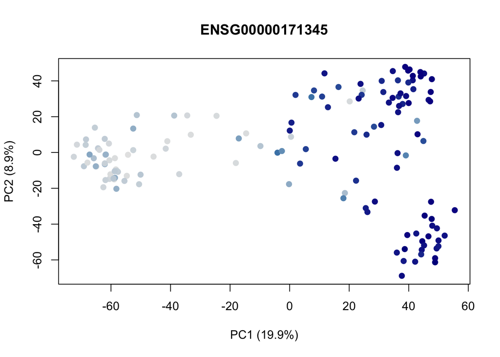

```r
gene <- "ENSG00000171345"
expr <- as.numeric(log_tpm[gene,])
pal <- colorRampPalette(c("grey90", "steelblue", "darkblue"))(100)
plot(pc1, pc2,
     pch = 19,

       xlab = paste0("PC1 (", var1, "%)"),
  ylab = paste0("PC2 (", var2, "%)"),
     main = gene,
       col = pal[cut(expr, breaks = 100)]
)
```

## Exercise 3

```r
sel <- sample(30)
log_tpm_small <- log_tpm[,sel]
tissue_small <- tissue[sel]
table(tissue_small)
```

```
tissue_small
  BREAST PANCREAS     SKIN
      13        6       11
```

To proceed with clustering analysis, we need to first compute distances between samples/cell lines using the `dist` function. If no specific options are provided to this function, Euclidean distance is used as the default distance metrics, as in the command below. To compute distances between samples (rather than genes), we need to first transpose the input data with the `t` function.

```r
dist_samples <- dist(t(log_tpm_small))
```

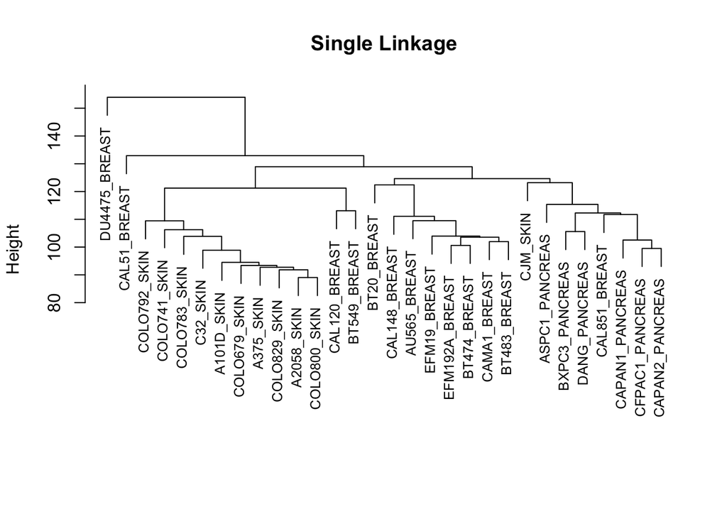

```r
hc_samples_sin <- hclust(dist_samples, method = "single")
plot(hc_samples_sin,
     xlab = "",
     sub = "",
     cex = 0.8,
     main = "Single Linkage")
```

In omics data analysis, Ward’s linkage is frequently used because it often produces more compact and interpretable clusters. Let’s apply this method and examine the resulting dendrogram.

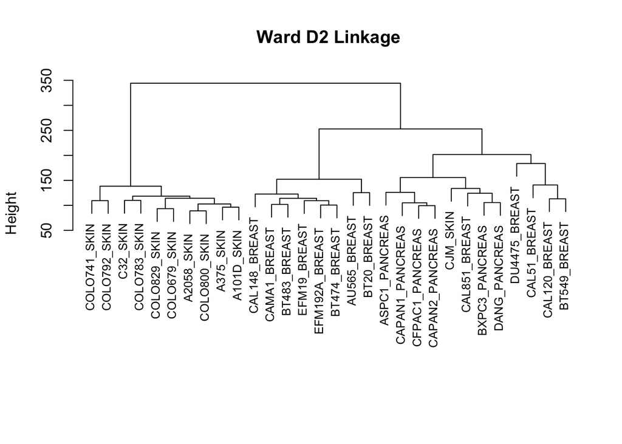

```r
hc_samples_war <- hclust(dist_samples, method = "ward.D2")
plot(hc_samples_war,
     xlab = "",
     sub = "",
     cex = 0.8,
     main = "Ward D2 Linkage")
```

❓ **Question:** Compare the dendrograms obtained using the two linkage methods: what differences do you observe?

## Exercise 4

The aim of this exercise is to perform binary classification of our RNA-seq datasets, aiming to identify skin cancer cell lines by distuinguishing them from breast cancer cell lines. To this end, we will first select from the original datasets only the samples corresponding to skin or breast cancer cell lines.

```r
sel <- which(tissue %in% c("BREAST", "SKIN"))
log_tpm_SK <- log_tpm[,sel]
tissue_SK <- factor(tissue[sel])
```

To identify skin cacer cell lines, we decide to first test a score based on the MKI67 gene, encoding the Ki-67 marker of proliferation, which is known to be upregulated in cancer cells. We can use GeneCards to see that the Ensembl identifier for the MKI67 is [ENSG00000148773](https://www.genecards.org/cgi-bin/carddisp.pl?gene=MKI67&keywords=MKI67). We can now define a score based on the log-scaled expression in TPM of this gene:

```r
mki67_score <- as.numeric(log_tpm_SK["ENSG00000148773",])
```

As we know the real class of every cell line (`tissue_SK`), we can perform Receiver Operating Characteristic Curve (ROC) analysis, testing the classification performance of this score at different cut-offs. For this analysis, we need to load the `pROC` R package.

```r
library(pROC)
```

Once the package is loaded, we can use its `roc` function to perform ROC analysis, and compute the area under the curve (AUC) of this score.

```r
mki67_roc <- roc(tissue_SK, mki67_score)
mki67_auc <- auc(mki67_roc)
print(paste0("AUC=", round(mki67_auc, 3)))
```

```
[1] "AUC=0.553"
```

The results of the analysis saved in `mki67_roc` can be visualized with the `plot` function.

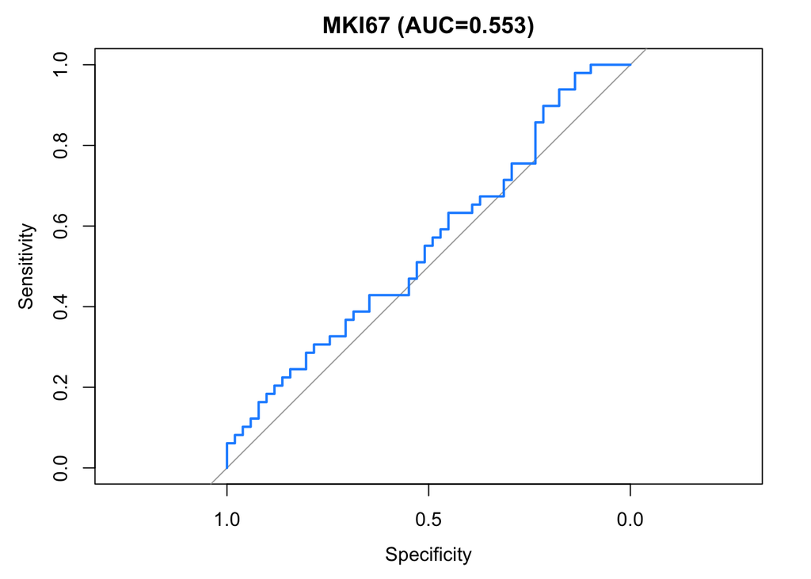

```r
plot(
  mki67_roc,
  col = "dodgerblue",
  lwd = 2,
  main = paste0("MKI67 (AUC=", round(mki67_auc, 3), ")")
)
```

❓ **Question:** How do you interpret these results?

**Click to see the answer**

**Answer:**

The AUC for this predictor is 0.553, only slightly above 0.5, which corresponds to random guessing. The ROC curve closely follows the diagonal, consistent with a near-random classifier. Overall, these results indicate that the MKI67 score is a suboptimal predictor for distinguishing skin cancer cell lines from breast cancer cell lines, likely due to expression of this marker in both tumor types.

We can try another classifier, which is focused on a gene that is characterized by a more specific expression in skin cancer. MART-1/melan-A is a protein antigen that is found on the surface of melanocytes, and is encoded by the MLANA gene.

❓ **Question:** How can we define a score based on MLANA gene expression and evaluate its classification performance through ROC analysis?

**Click to see the answer**

**Answer:**

```r
mlana_score <- as.numeric(log_tpm_SK["ENSG00000120215",])
mlana_roc <- roc(tissue_SK, mlana_score)
mlana_auc <- auc(mlana_roc)
print(paste0("AUC=", round(mlana_auc, 3)))
```

```
[1] "AUC=0.906"
```

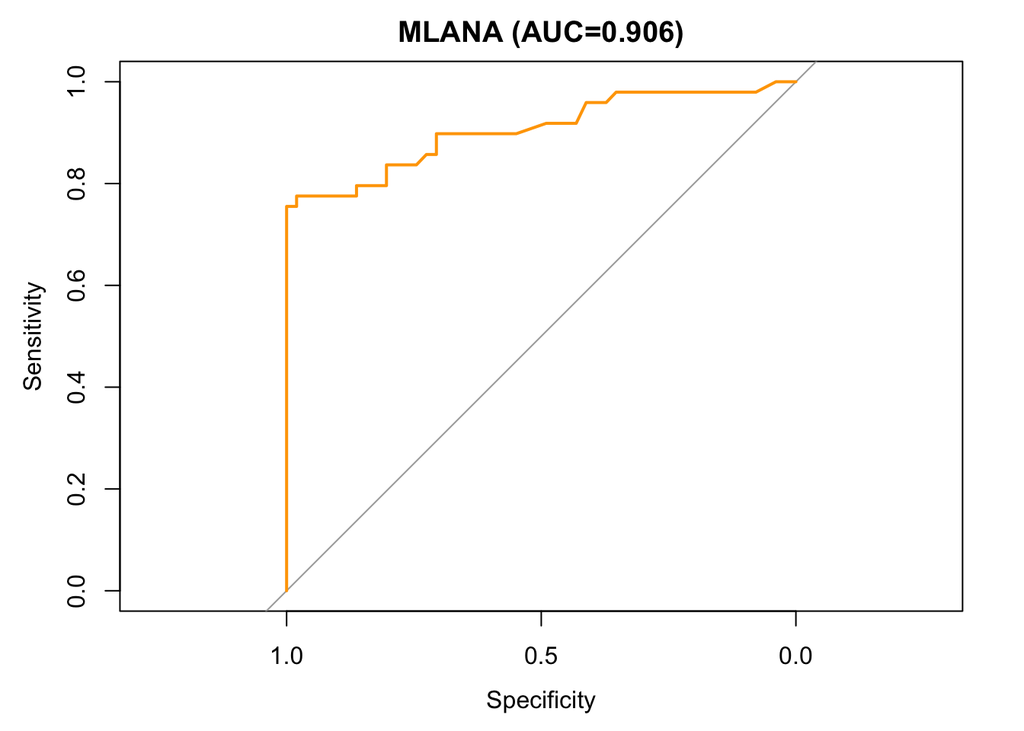

```r
plot(
  mlana_roc,
  col = "orange",
  lwd = 2,
  main = paste0("MLANA (AUC=", round(mlana_auc, 3), ")")
)
```

We can also visualize the results from both predictors/scores in the same AUC plot.

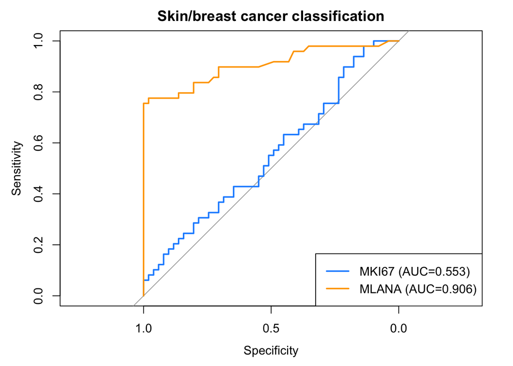

```r
plot(mki67_roc,
     col = "dodgerblue",
     lwd = 2,
     main = "Skin/breast cancer classification")

lines(mlana_roc,
      col = "orange",
      lwd = 2)

legend("bottomright",
       legend = c(paste0("MKI67 (AUC=", round(mki67_auc, 3), ")"),
                paste0("MLANA (AUC=", round(mlana_auc, 3), ")")),
       col = c("dodgerblue","orange"),
       lwd = 2)
```

❓ **Question:** How does the MLANA score perform compared to the MKI67 score in the classification of skin versus breast cancer cell lines, based on ROC analysis

**Click to see the answer**

**Answer:**

The AUC of 0.906 indicates that MLANA is an extremely strong predictor in this task and dataset. Instead, MKI67 provides provide quasi-random classification, as reflected by its much lower AUC (0.553)

## Exercise X

This exercise focuses on the analysis of an RNA-seq dataset from (Mariathasan et al. 2018)[https://www.nature.com/articles/nature25501]. In this study, the authors performed RNA-seq on tumor samples collected pre-treatment from patients with bladder cancer who received cancer immunotherapy. The matrix of gene TPM and information on therapeutic response can be downloaded in the form or an R file (“Mariathasan_data.rdata”) from the course OpenOLAT entry at [this link](https://lms.uibk.ac.at/auth/RepositoryEntry/5944246577/CourseNode/113086671488191). **Note**: you need to be logged in to access the file.

By loading the file in R, we can see that it includes:

- A data.frame, called `tpm`, with the TPM across 31,087 genes and 192 samples. Gene symbols are used as row names.
- A vector, called `response`, containing threapeutic information for all the patients in this cohort indicating whether they showed response to immunotherapy (‘R’) or were instead non-responsers.

```r
load("Mariathasan_data.rda", verbose = TRUE)
```

```
Loading objects:
  tpm
  response
```

```r
dim(tpm)
```

```
[1] 31087   192
```

```r
tpm[1:3, 1:3]
```

```
     SAM7f0d9cc7f001 SAM4305ab968b90 SAMcf018fee2acd
A1BG        1.882844       0.2902511       1.3514397
NAT2        0.000000       0.0000000       0.5478687
ADA        13.123289      12.3629616       5.6552400
```

```r
length(response)
```

```
[1] 192
```

```r
head(response)
```

```
[1] NR NR NR NR NR NR
Levels: NR R
```

❓ **Question:** How many responders and non-responders? are there in this dataset? *Hint*: use `table`.

Before starting the analysis, let’s convert the TPM to logarithmic scale.

```r
log_tpm <- log(tpm+1)
```

❓ **Question:** How many responders and non-responders? are there in this dataset? *Hint*: use `table`.

Let’s use `log_tpm` data to perform PCA analysis and visualize the samples in 2-dimensional PCA space.

❓ **Question:** How much variance is explained by PC1 and PC2?

❓ **Question:** Do samples separate in PCA space according to therapeutic response?

❓ **Question:** Which is the gene with the largest absolute PC1 loading, and the one with the largest PC2 loading? Visualize their expression level in PC space.

We want to define three scores aiming at predicting patients’ response to cancer immunotherapy:

- **PDL1**: The Mariathasan study focuses on the inhibition of PD-L1. The level of PD-L1 expression has been identified as predictive of response to anti-PDL1 immunotherapy. Therefore, we can define a score based on PD-L1 expression in log-TPM. However, it is important to note that PD-L1 is not the official gene symbol and, thus, is not present in the Mariathasan dataset; the correct symbol is [CD274](https://www.genenames.org/data/gene-symbol-report/#!/hgnc_id/HGNC:176350).
- **CD8A**: CD8⁺ T cells are a subpopulation of T lymphocytes that can recognize and kill tumor cells. They have been associated with favorable patient outcomes and response to cancer immunotherapy ([Fridman et al. 2017](https://doi.org/10.1038/nrclinonc.2017.101)). These cells are characterized by high expression of their defining markers, CD8A and CD8B. We can define a second score as the sum of the expression (log-TPM) of these two genes.
- **CYT**: In a recent study (Rooney et al. 2015), the authors defined a simple score to quantify the killing capacity of cytotoxic T cells and natural killer (NK) cells. This cytolytic activity (CYT) score, which we can use as our third predictor, is based on the sum of the expression (log-TPM) of the granzyme A (GZMA) and perforin (PRF1) genes.

Let’s compute these three scores (PDL1, CD8A, CYT) and evaluate theire ability to classify patients’ response (with “R” and “NR” ground-truth labels saved in the `response` object) via ROC analysis with the `pROC` package. Compare all three predictors in a single ROC plot, which should also report their AUC.

❓ **Question:** Based on the plot and AUC values, which score shows the best classification performance, and which one the worst?